# Regression Models Project Kirsten Frank

Kirsten Frank

September 9, 2014

# Executive Summary

## Project description.

Using the data in the mtcars dataset, determine whether manual cars have lower mpg than automatic. Derive an estimate of the difference and interpret the difference.

## Considerations

The mpg of AM=1 (manual transmission) is clearly higher. At a first glance, this is our answer. Manual transmissions have higher mpg (more gas efficiency). But look at weight in Plot 2 in the Appendix.

The weight of AM=1 (manual) is clearly lower, so the weight varies with transmission type. We might expect weight to be related to mpg (see Plot 3).

And, yes, heavier cars have lower mpg.

Yes

Now we do a simple (or marginal) fit of mpg to transmission type. The summary shows the fit.

```
##
## Call:
## lm(formula = mpg ~ am, data = mtcars)
##
## Residuals:
##    Min     1Q Median     3Q    Max
## -9.392 -3.092 -0.297  3.244  9.508
##
## Coefficients:
##             Estimate Std. Error t value Pr(>|t|)
## (Intercept)    17.15       1.12   15.25  1.1e-15 ***
## am              7.24       1.76    4.11  0.00029 ***
## ---
## Signif. codes:  0 '***' 0.001 '**' 0.01 '*' 0.05 '.' 0.1 ' ' 1
##
## Residual standard error: 4.9 on 30 degrees of freedom
## Multiple R-squared:  0.36,   Adjusted R-squared:  0.338
## F-statistic: 16.9 on 1 and 30 DF,  p-value: 0.000285
```

The fit gives us a beta1 of 7.2449; this the change in mpg when switching from automatic to manual transmission. This model explains 36 % of the variance.

We then look at the residuals, comparing them to weight and separately to horsepower. We want to see if weight and horsepower are missing model factors.

The residuals are not random with respect to mpg, horsepower or weight. The residuals basically make a pair of straight lines with mpg, so something significant is missing. The residuals are lower (negative) at higher weight and higher horsepower. Now, we can color in the residuals vs mpg plot with transmission type, weight, displacement, horsepower, gear, or cylinders (see Plots 5-10)

All of these variables show different distribution between automatic and manual transmission. So we can add them one by one in a nested set of fits. First, we will try with adding horsepower (See plots 11-12).

```
##
## Call:
## lm(formula = mpg ~ am + hp, data = mtcars)
##
## Residuals:
##    Min     1Q Median     3Q    Max
## -4.384 -2.264  0.137  1.697  5.866
##
## Coefficients:
##             Estimate Std. Error t value Pr(>|t|)
## (Intercept) 26.58491    1.42509   18.65  < 2e-16 ***
## am           5.27709    1.07954    4.89  3.5e-05 ***
## hp          -0.05889    0.00786   -7.50  2.9e-08 ***
## ---
## Signif. codes:  0 '***' 0.001 '**' 0.01 '*' 0.05 '.' 0.1 ' ' 1
##
## Residual standard error: 2.91 on 29 degrees of freedom
## Multiple R-squared:  0.782,  Adjusted R-squared:  0.767
## F-statistic:   52 on 2 and 29 DF,  p-value: 2.55e-10
```

```
##           Mazda RX4       Mazda RX4 Wag          Datsun 710
##               0.079               0.079               0.085
##      Hornet 4 Drive   Hornet Sportabout             Valiant
##               0.071               0.054               0.075
##          Duster 360           Merc 240D            Merc 230
##               0.105               0.123               0.084
##            Merc 280           Merc 280C          Merc 450SE
##               0.063               0.063               0.055
##          Merc 450SL         Merc 450SLC  Cadillac Fleetwood
##               0.055               0.055               0.067
## Lincoln Continental   Chrysler Imperial            Fiat 128
##               0.074               0.088               0.104
##         Honda Civic      Toyota Corolla       Toyota Corona
##               0.118               0.105               0.082
##    Dodge Challenger         AMC Javelin          Camaro Z28
##               0.053               0.053               0.105
##    Pontiac Firebird           Fiat X1-9       Porsche 914-2
##               0.054               0.104               0.086
##        Lotus Europa      Ford Pantera L        Ferrari Dino
##               0.078               0.214               0.094
##       Maserati Bora          Volvo 142E
##               0.393               0.079
```

```
##                     (Intercept)     am     hp
## Mazda RX4                -0.068 -0.330  0.076
## Mazda RX4 Wag            -0.068 -0.330  0.076
## Datsun 710               -0.110 -0.252  0.125
## Hornet 4 Drive            0.107 -0.082 -0.064
## Hornet Sportabout         0.063 -0.116  0.035
## Valiant                  -0.203  0.151  0.127
## Duster 360               -0.077 -0.070  0.187
## Merc 240D                 0.194 -0.117 -0.151
## Merc 230                  0.177 -0.124 -0.118
## Merc 280                 -0.010  0.008  0.005
## Merc 280C                -0.110  0.093  0.056
## Merc 450SE                0.009 -0.019  0.008
## Merc 450SL                0.028 -0.061  0.025
## Merc 450SLC              -0.017  0.036 -0.015
## Cadillac Fleetwood       -0.001  0.174 -0.187
## Lincoln Continental       0.031  0.140 -0.196
## Chrysler Imperial        -0.036 -0.059  0.116
## Fiat 128                  0.254  0.292 -0.287
## Honda Civic               0.110  0.097 -0.125
## Toyota Corolla            0.356  0.402 -0.403
## Toyota Corona             0.060 -0.042 -0.039
## Dodge Challenger         -0.107  0.121  0.023
## AMC Javelin              -0.122  0.137  0.026
## Camaro Z28               -0.041 -0.037  0.099
## Pontiac Firebird          0.077 -0.140  0.042
## Fiat X1-9                -0.037 -0.043  0.042
## Porsche 914-2            -0.016 -0.034  0.018
## Lotus Europa              0.067  0.402 -0.076
## Ford Pantera L            0.073 -0.066 -0.082
## Ferrari Dino              0.080 -0.167 -0.091
## Maserati Bora            -0.815  0.564  0.922
## Volvo 142E               -0.066 -0.301  0.074
```

The beta1 coefficient against transmission type is 5.2771. This is different than the beta1 coefficient we got before. This is the change in mpg going from an automatic to a manual transmission, holding horsepower constant.

This model explains 78 % of the variance.

Let’s see what the interaction is. See plots 13-18.

```
##
## Call:
## lm(formula = mpg ~ am * hp, data = mtcars)
##
## Residuals:
##    Min     1Q Median     3Q    Max
## -4.382 -2.270  0.134  1.706  5.875
##
## Coefficients:
##              Estimate Std. Error t value Pr(>|t|)
## (Intercept) 26.624848   2.182943   12.20    1e-12 ***
## am           5.217653   2.665093    1.96     0.06 .
## hp          -0.059137   0.012945   -4.57    9e-05 ***
## am:hp        0.000403   0.016460    0.02     0.98
## ---
## Signif. codes:  0 '***' 0.001 '**' 0.01 '*' 0.05 '.' 0.1 ' ' 1
##
## Residual standard error: 2.96 on 28 degrees of freedom
## Multiple R-squared:  0.782,  Adjusted R-squared:  0.759
## F-statistic: 33.5 on 3 and 28 DF,  p-value: 2.11e-09
```

Now the interpretation of the beta1 is a bit more complex, the beta1 of 5.2177 is the difference between automatic and manual transmissions for a car with 0 hp. We would rather look at the mean of reasonable car horsepower, 147 hp. At that horsepower, the change in mpg from automatic to manual is 5.2768.

This model explains 78 % of the variance. This is not a big improvement, so interaction is not the best explanation.

Maserati Bora is the most extreme value.

```
##
## Call:
## lm(formula = mpg ~ am + hp + wt, data = mtcars)
##
## Residuals:
##    Min     1Q Median     3Q    Max
## -3.422 -1.792 -0.379  1.225  5.532
##
## Coefficients:
##             Estimate Std. Error t value Pr(>|t|)
## (Intercept) 34.00288    2.64266   12.87  2.8e-13 ***
## am           2.08371    1.37642    1.51  0.14127
## hp          -0.03748    0.00961   -3.90  0.00055 ***
## wt          -2.87858    0.90497   -3.18  0.00357 **
## ---
## Signif. codes:  0 '***' 0.001 '**' 0.01 '*' 0.05 '.' 0.1 ' ' 1
##
## Residual standard error: 2.54 on 28 degrees of freedom
## Multiple R-squared:  0.84,   Adjusted R-squared:  0.823
## F-statistic:   49 on 3 and 28 DF,  p-value: 2.91e-11
```

This model explains 84 % of the variance.

The transmission type does not significantly affect the mpg, after adjustment for horsepower and weight. Beta1 is 2.0837.

Maserati Bora is the most extreme value.

You can explain even more of the variance using an interaction term with horsepower and weight.

```
##
## Call:
## lm(formula = mpg ~ am + hp * wt, data = mtcars)
##
## Residuals:
##    Min     1Q Median     3Q    Max
## -2.985 -1.658 -0.741  1.436  4.527
##
## Coefficients:
##             Estimate Std. Error t value Pr(>|t|)
## (Intercept) 49.45224    5.28073    9.36  5.7e-10 ***
## am           0.12511    1.33343    0.09  0.92594
## hp          -0.11930    0.02655   -4.49  0.00012 ***
## wt          -8.10056    1.78933   -4.53  0.00011 ***
## hp:wt        0.02749    0.00847    3.24  0.00313 **
## ---
## Signif. codes:  0 '***' 0.001 '**' 0.01 '*' 0.05 '.' 0.1 ' ' 1
##
## Residual standard error: 2.19 on 27 degrees of freedom
## Multiple R-squared:  0.885,  Adjusted R-squared:  0.868
## F-statistic: 51.8 on 4 and 27 DF,  p-value: 2.76e-12
```

To compare the fits (which are nested, meaning each one contains the terms of the previous), we use

```
## Analysis of Variance Table
##
## Model 1: mpg ~ am
## Model 2: mpg ~ am + hp
## Model 3: mpg ~ am + hp + wt
## Model 4: mpg ~ am + hp * wt
##   Res.Df RSS Df Sum of Sq    F  Pr(>F)
## 1     30 721
## 2     29 245  1       475 99.0 1.6e-10 ***
## 3     28 180  1        65 13.6  0.0010 **
## 4     27 130  1        51 10.5  0.0031 **
## ---
## Signif. codes:  0 '***' 0.001 '**' 0.01 '*' 0.05 '.' 0.1 ' ' 1
```

In this comparison of fits, we look at the decrease in RSS to see how much the additional terms improve the fit, versus just add complexity to the model. One rule of thumb is that the RSS should approximately halve with each term.

## Appendix Plots are found here.

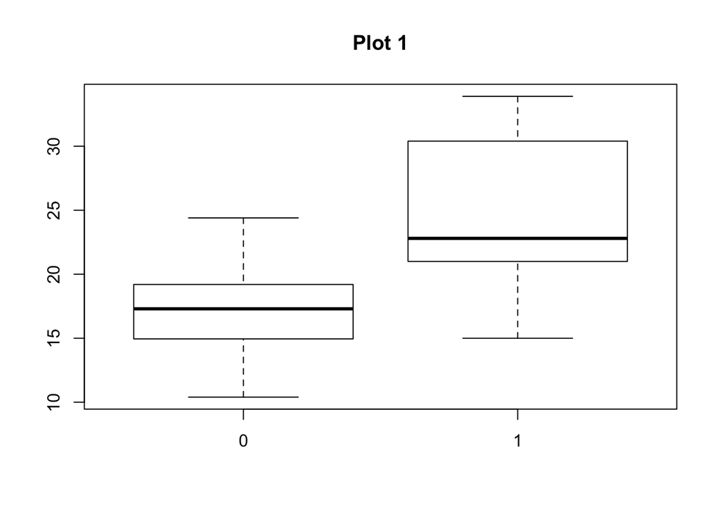

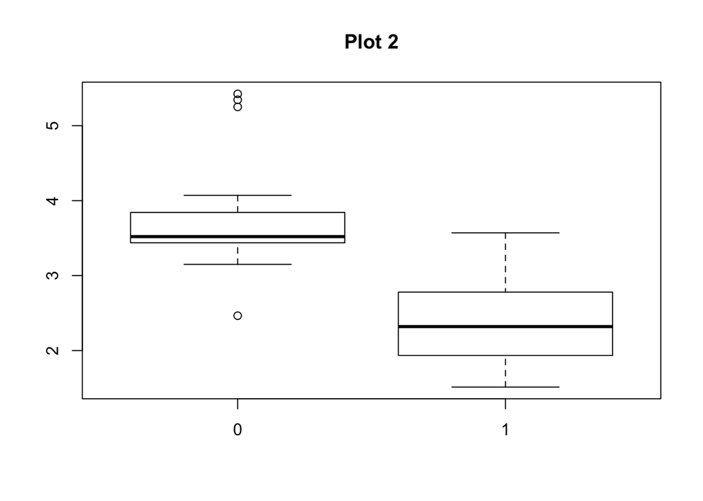

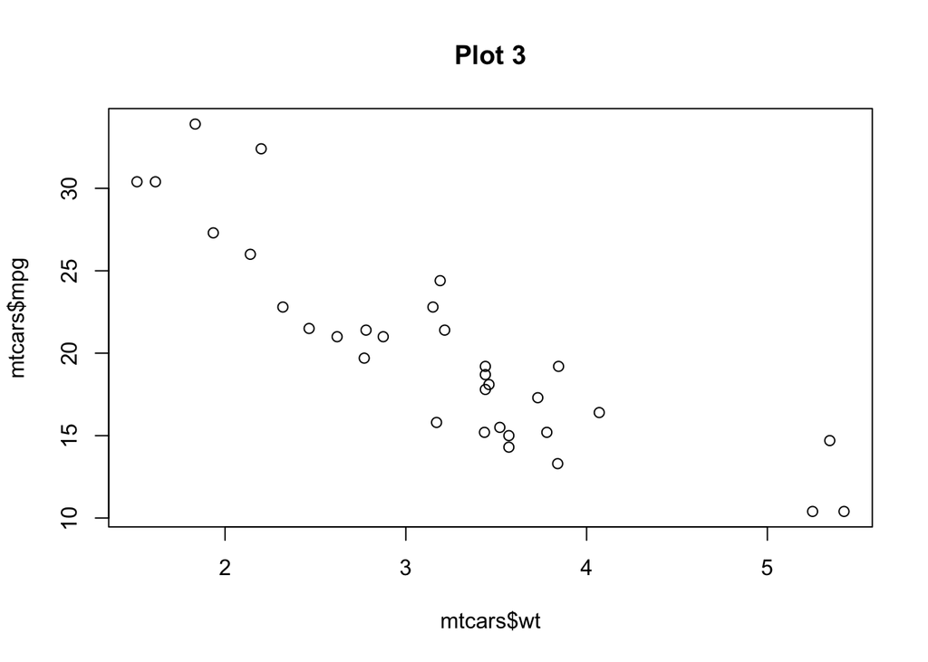

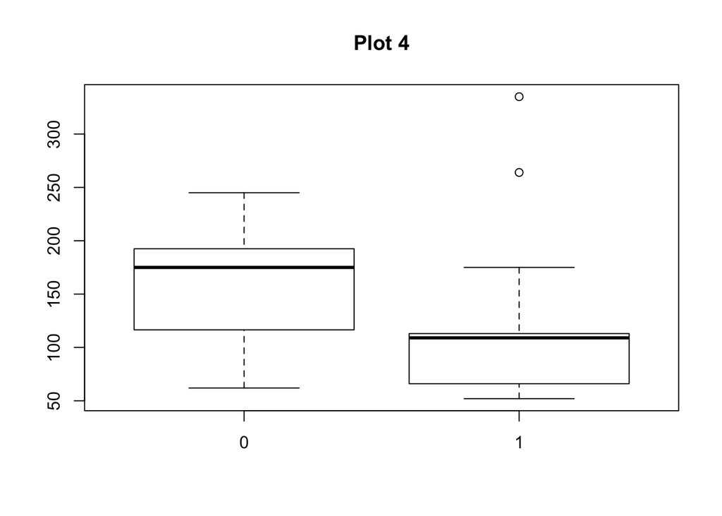

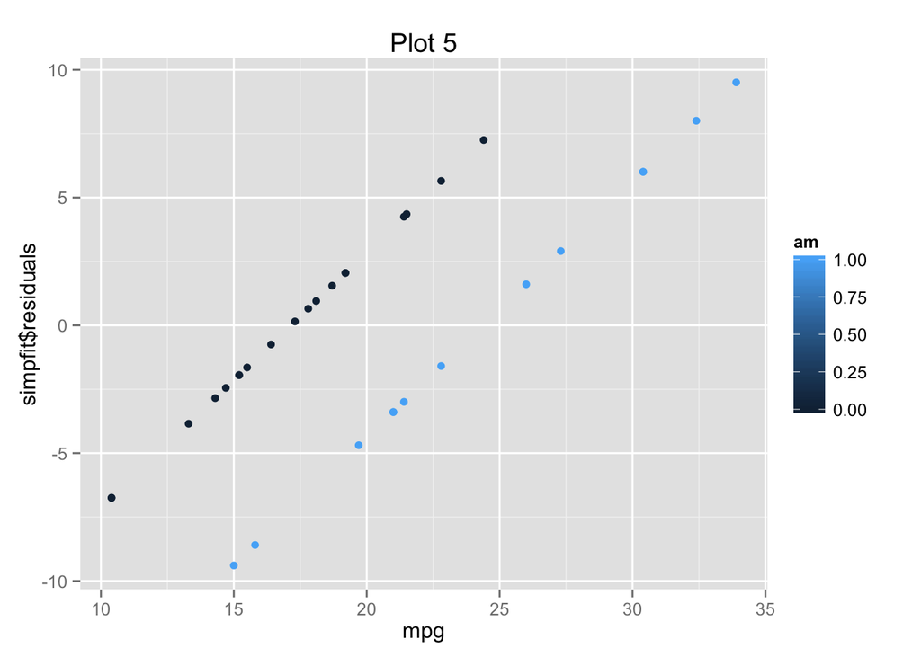

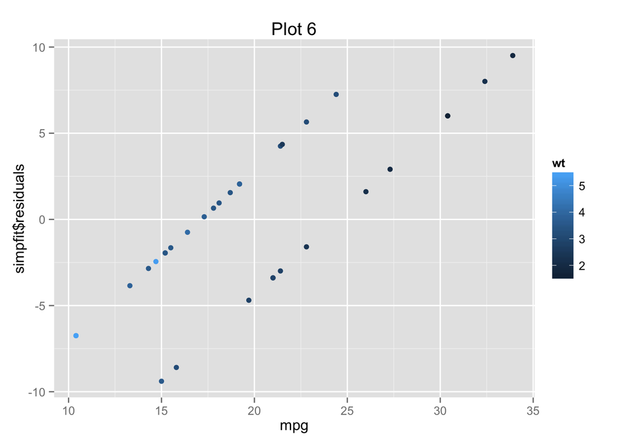

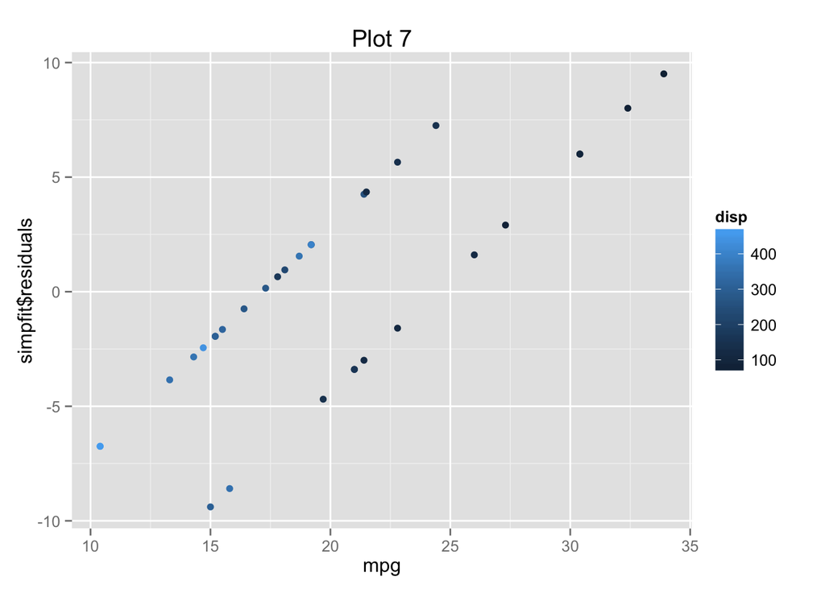

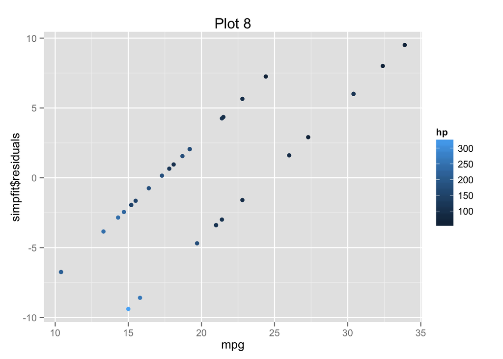

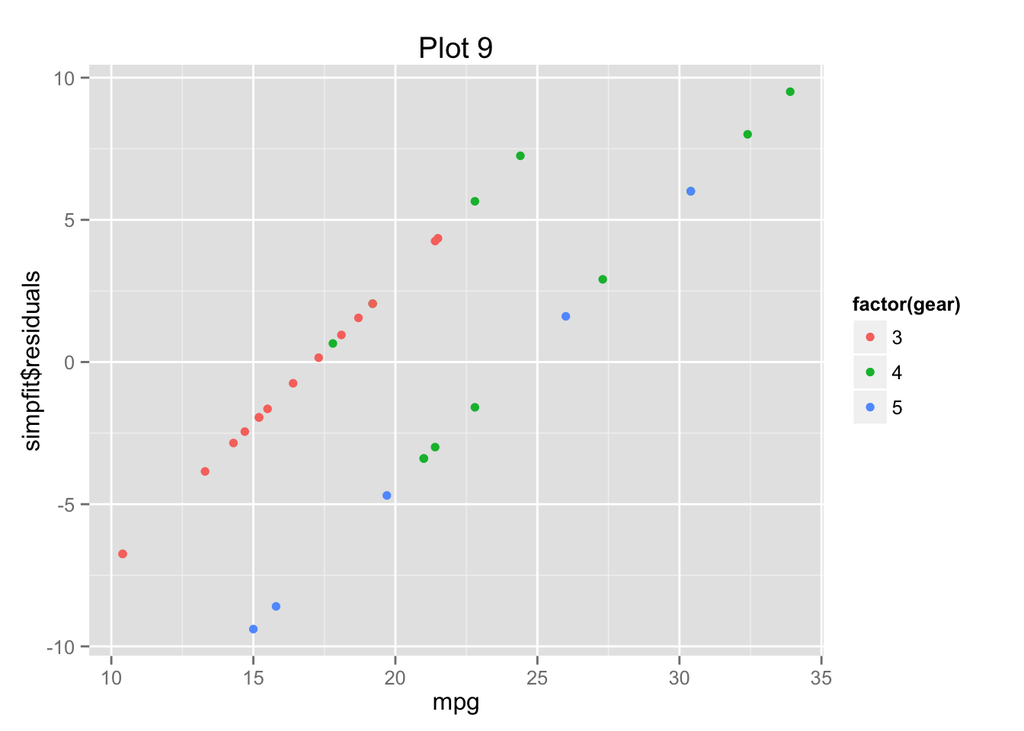

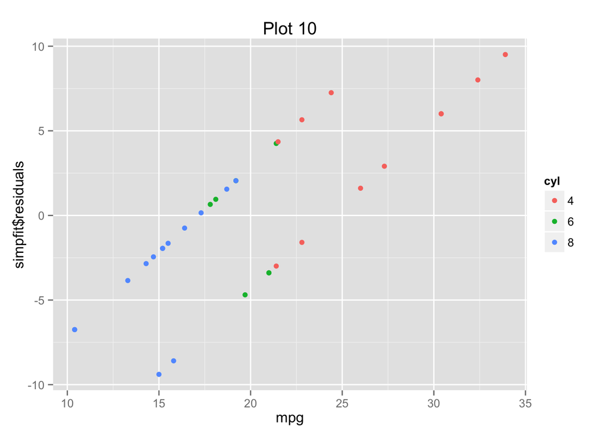

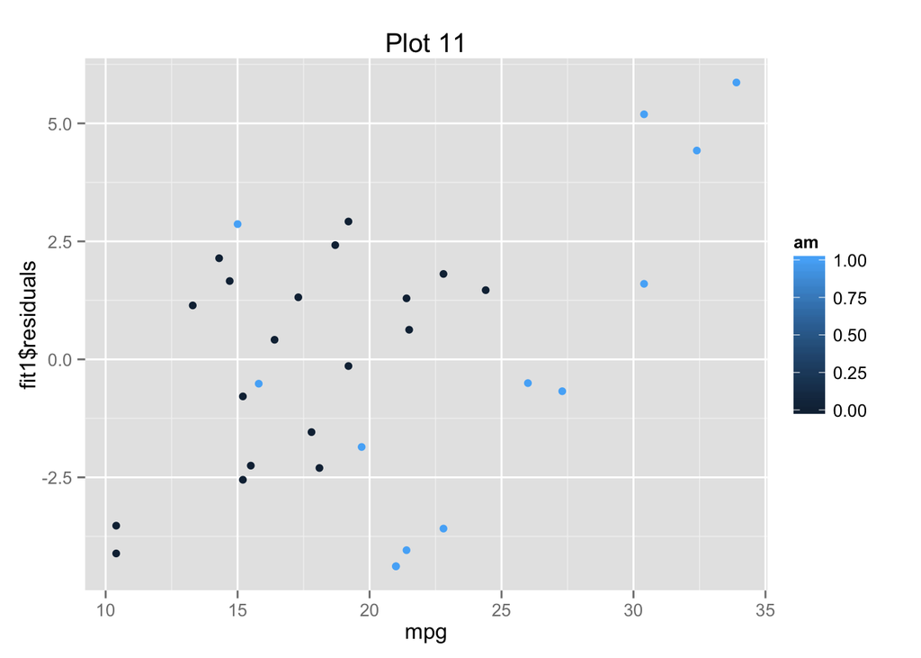

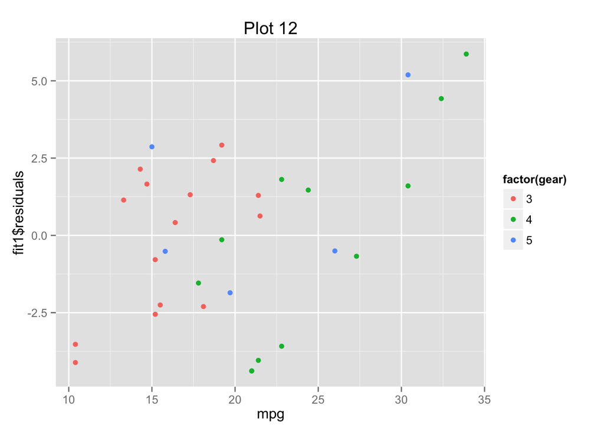

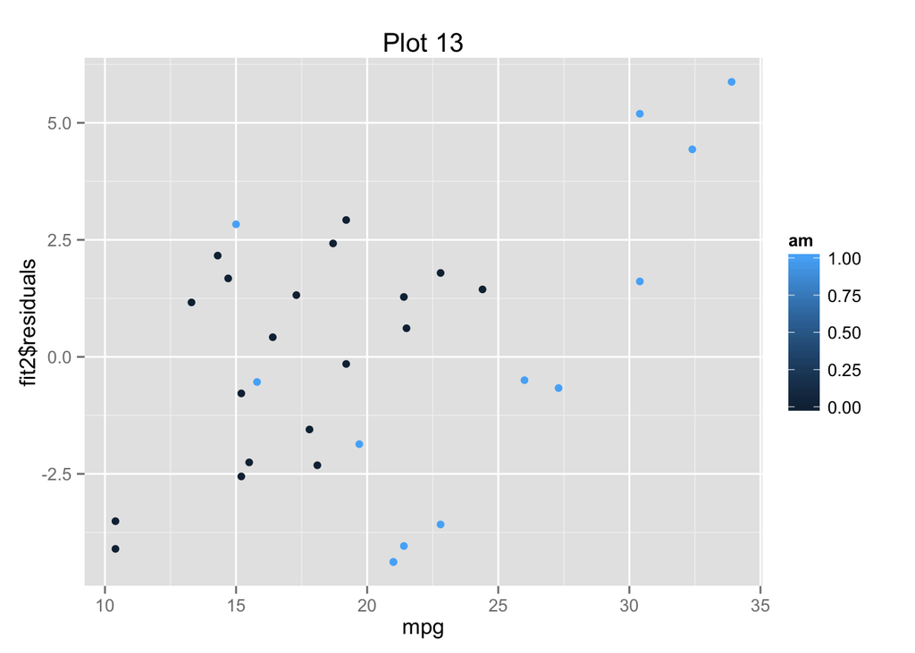

```r
resmpg2<-ggplot(mtcars,aes(x=mpg,y=fit2$residuals))
resmpg2 + geom_point(aes(color=am)) +ggtitle("Plot 13")
```

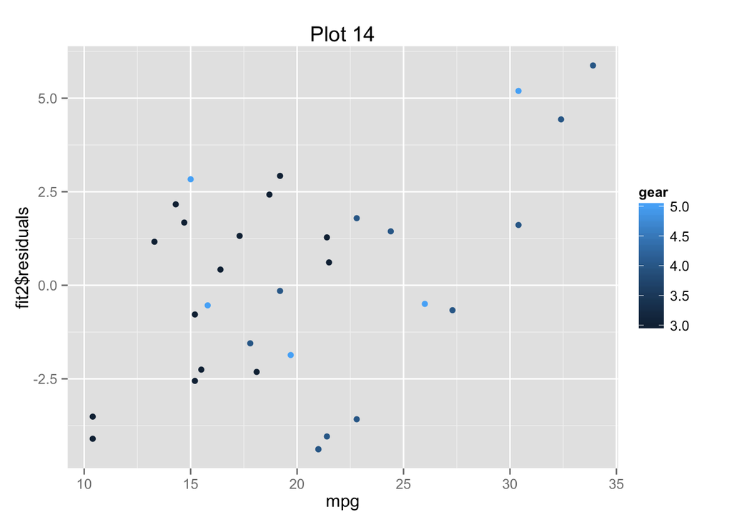

```r
resmpg2 + geom_point(aes(color=gear)) + ggtitle("Plot 14")
```

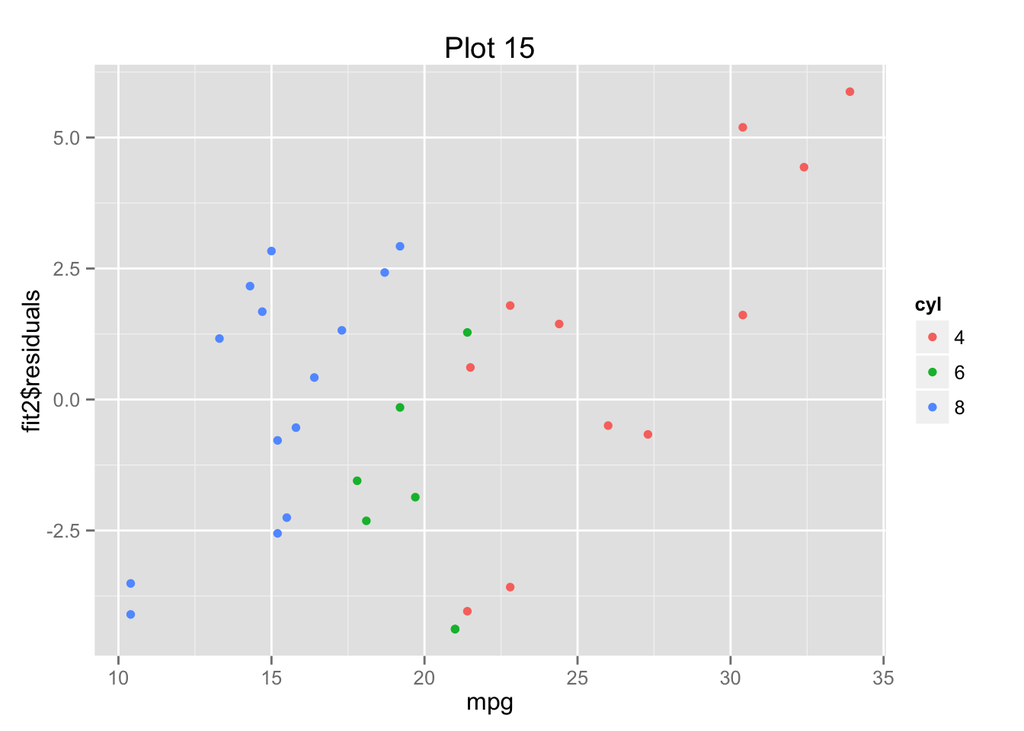

```r
resmpg2 + geom_point(aes(color=cyl)) + ggtitle("Plot 15")
```

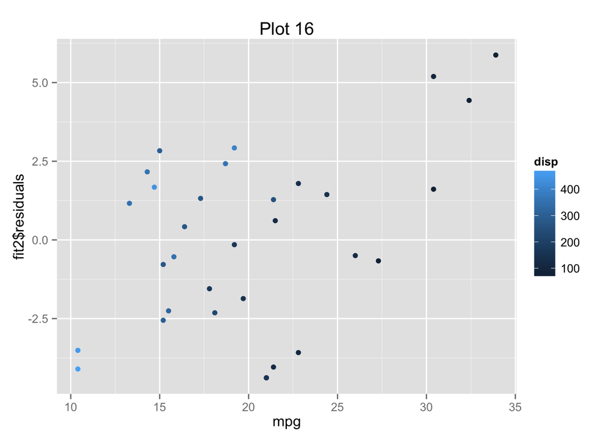

```r
resmpg2 + geom_point(aes(color=disp)) + ggtitle("Plot 16")
```

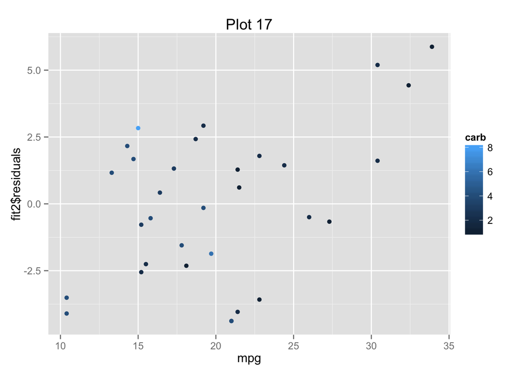

```r
resmpg2 + geom_point(aes(color=carb)) + ggtitle("Plot 17")
```

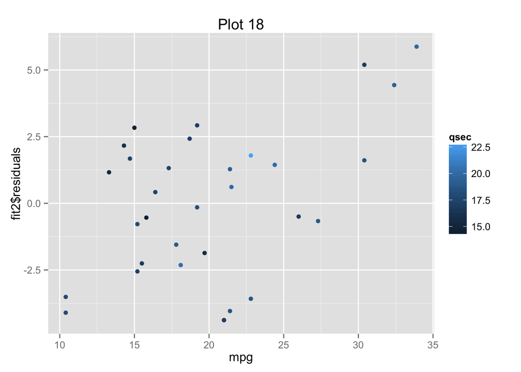

```r
resmpg2 + geom_point(aes(color=qsec)) + ggtitle("Plot 18")
```

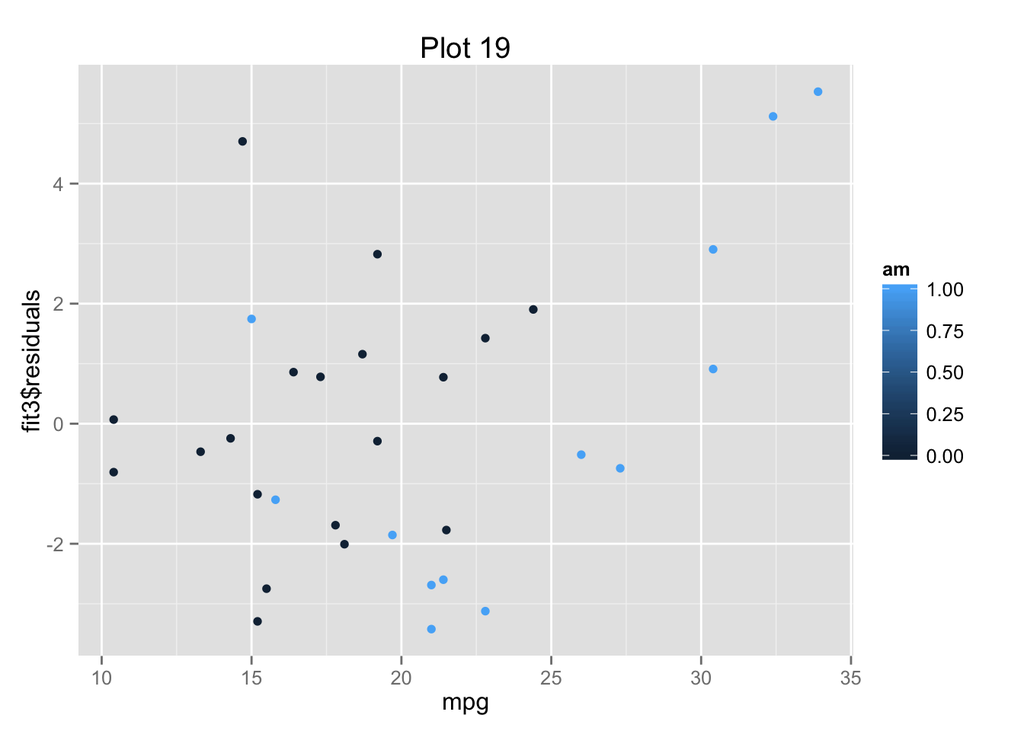

```r
resmpg3<-ggplot(mtcars,aes(x=mpg,y=fit3$residuals))
resmpg3 + geom_point(aes(color=am)) + ggtitle("Plot 19")
```

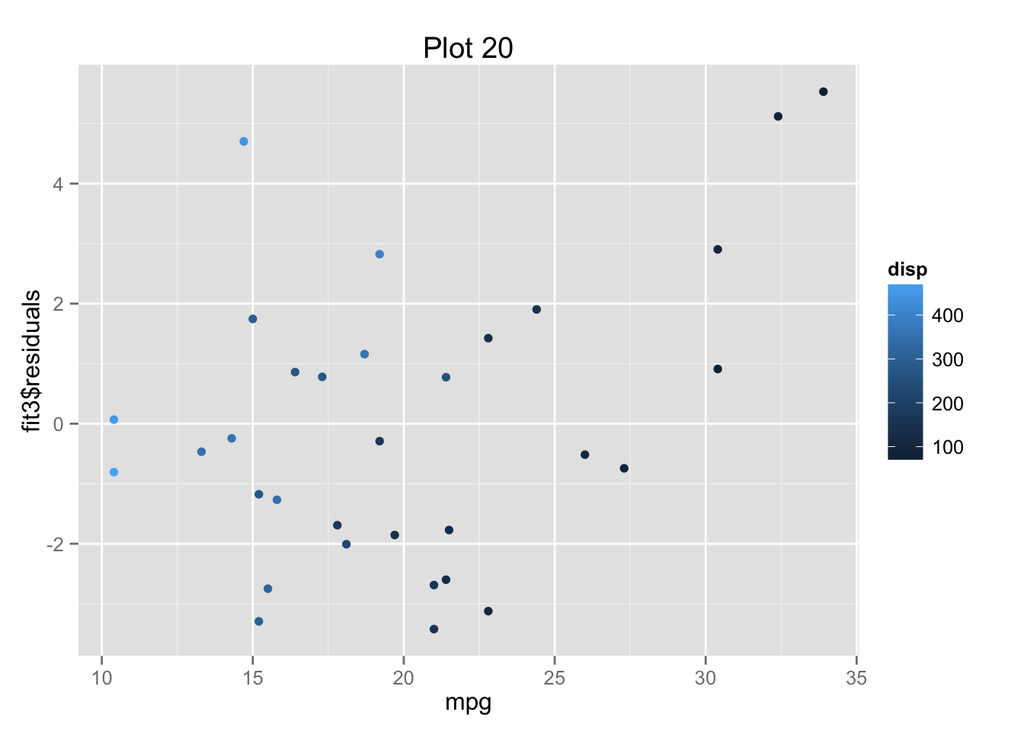

```r
resmpg3 + geom_point(aes(color=disp)) + ggtitle("Plot 20")
```

##Version Information

```r
VersionInfo<-R.Version()
print(VersionInfo$platform)
```

```
## [1] "x86_64-apple-darwin13.1.0"
```

```r
print(VersionInfo$version.string)
```

```
## [1] "R version 3.1.0 (2014-04-10)"
```

Data is originally from the 1974 *Motor Trend* US magazine.

```r
summary(mtcars)
```

```
##       mpg       cyl         disp             hp             drat
##  Min.   :10.4   4:11   Min.   : 71.1   Min.   : 52.0   Min.   :2.76
##  1st Qu.:15.4   6: 7   1st Qu.:120.8   1st Qu.: 96.5   1st Qu.:3.08
##  Median :19.2   8:14   Median :196.3   Median :123.0   Median :3.69
##  Mean   :20.1          Mean   :230.7   Mean   :146.7   Mean   :3.60
##  3rd Qu.:22.8          3rd Qu.:326.0   3rd Qu.:180.0   3rd Qu.:3.92
##  Max.   :33.9          Max.   :472.0   Max.   :335.0   Max.   :4.93
##        wt            qsec            vs              am
##  Min.   :1.51   Min.   :14.5   Min.   :0.000   Min.   :0.000
##  1st Qu.:2.58   1st Qu.:16.9   1st Qu.:0.000   1st Qu.:0.000
##  Median :3.33   Median :17.7   Median :0.000   Median :0.000
##  Mean   :3.22   Mean   :17.8   Mean   :0.438   Mean   :0.406
##  3rd Qu.:3.61   3rd Qu.:18.9   3rd Qu.:1.000   3rd Qu.:1.000
##  Max.   :5.42   Max.   :22.9   Max.   :1.000   Max.   :1.000
##       gear           carb          normwt           shortwt
##  Min.   :3.00   Min.   :1.00   Min.   :-1.7751   Min.   :0.756
##  1st Qu.:3.00   1st Qu.:2.00   1st Qu.:-0.7068   1st Qu.:1.291
##  Median :4.00   Median :2.00   Median : 0.0369   Median :1.663
##  Mean   :3.69   Mean   :2.81   Mean   :-0.0708   Mean   :1.609
##  3rd Qu.:4.00   3rd Qu.:4.00   3rd Qu.: 0.3219   3rd Qu.:1.805
##  Max.   :5.00   Max.   :8.00   Max.   : 2.1359   Max.   :2.712
```